# Time-dependent GeoTox

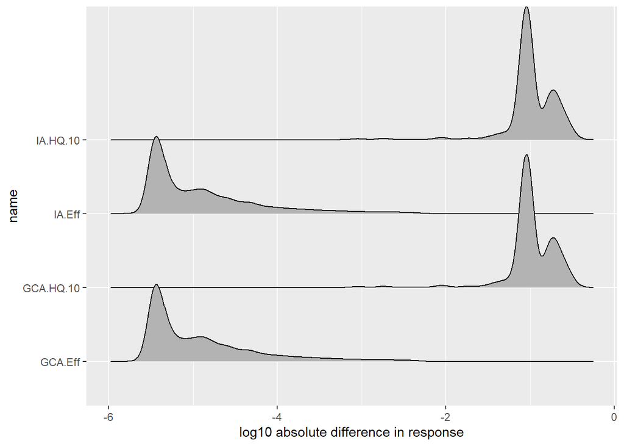

```r
ggplot(tidyr::pivot_longer(data.table(td_sensitivity_constant_pcp[[1]])[, lapply(.SD, function(t) {abs(diff(t))}), .SDcols = 2:5][, sample := 1:.N], cols = !sample) |>
         dplyr::filter(!is.na(value) & value >= 1E-15), aes(x = log10(value), y = name)) +
  ggridges::geom_density_ridges() +
  xlab('log10 absolute difference in response')
```

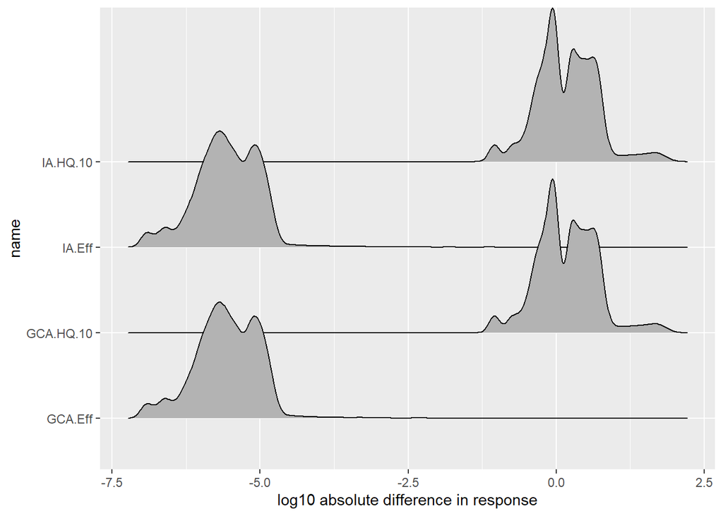

```r
# Plots for BPA exposures sensitivity
ggplot(tidyr::pivot_longer(data.table(td_sensitivity_acute_bpa[[1]])[, lapply(.SD, function(t) {abs(diff(t))}), .SDcols = 2:5][, sample := 1:.N], cols = !sample) |>
         dplyr::filter(!is.na(value) & value >= 1E-15), aes(x = log10(value), y = name)) +
  ggridges::geom_density_ridges() +
  xlab('log10 absolute difference in response')
```

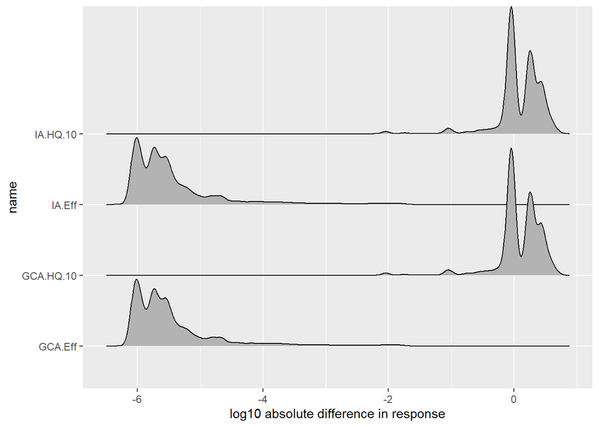

```r
ggplot(tidyr::pivot_longer(data.table(td_sensitivity_periodic_bpa[[1]])[, lapply(.SD, function(t) {abs(diff(t))}), .SDcols = 2:5][, sample := 1:.N], cols = !sample) |>
         dplyr::filter(!is.na(value) & value >= 1E-15), aes(x = log10(value), y = name)) +
  ggridges::geom_density_ridges() +
  xlab('log10 absolute difference in response')
```

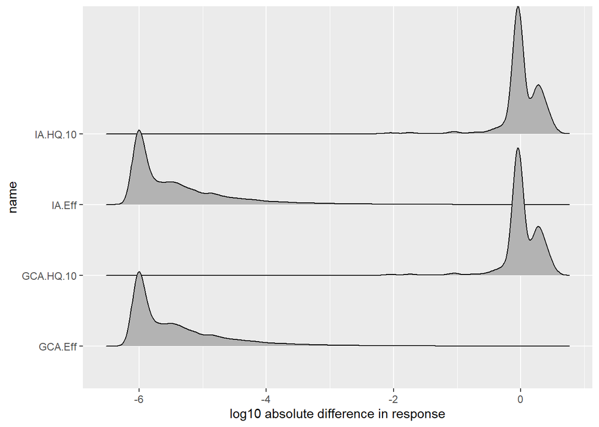

```r
ggplot(tidyr::pivot_longer(data.table(td_sensitivity_constant_bpa[[1]])[, lapply(.SD, function(t) {abs(diff(t))}), .SDcols = 2:5][, sample := 1:.N], cols = !sample) |>
         dplyr::filter(!is.na(value) & value >= 1E-15), aes(x = log10(value), y = name)) +
  ggridges::geom_density_ridges() +
  xlab('log10 absolute difference in response')
```

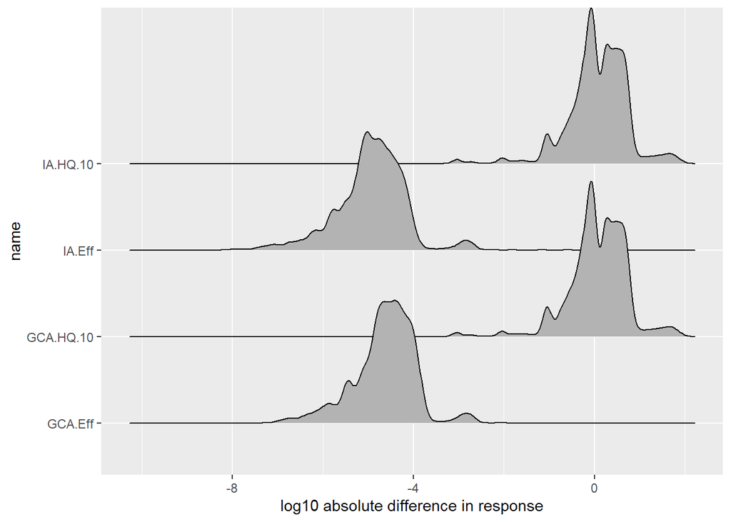

```r
# Plot for mixture exposure scenario (Acute for PCP and Periodic for BPA)
ggplot(tidyr::pivot_longer(data.table(td_sensitivity_mixture[[1]])[, lapply(.SD, function(t) {abs(diff(t))}), .SDcols = 2:5][, sample := 1:.N], cols = !sample) |>
         dplyr::filter(!is.na(value) & value >= 1E-15), aes(x = log10(value), y = name)) +
  ggridges::geom_density_ridges() +
  xlab('log10 absolute difference in response')
```

For a signed version of this, to differentiate increases from decreases in the response curve, we can do the following.

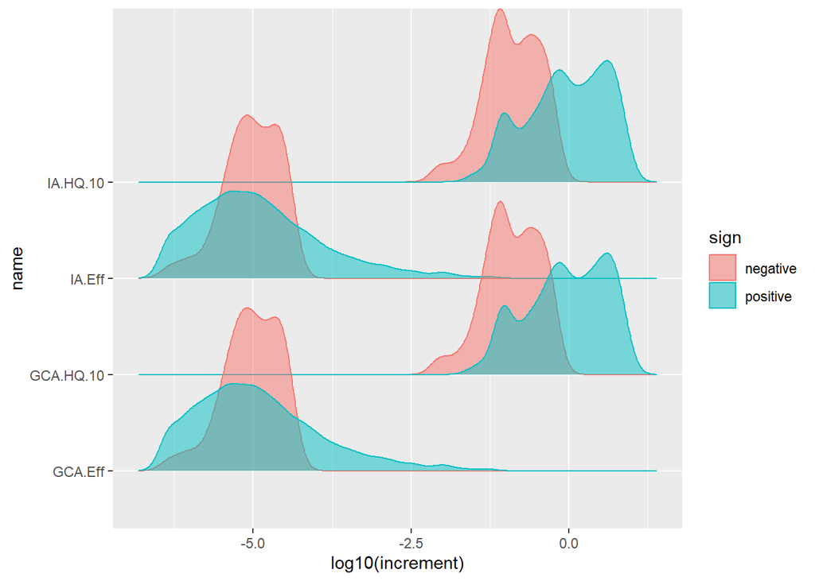

```r
# Signed sensitivity for PCP scenarios
td_sensitivity_acute_signed_pcp <- tidyr::pivot_longer(data.table(td_sensitivity_acute_pcp[[1]])[, lapply(.SD, diff), .SDcols = 2:5][, sample := 1:.N], cols = !sample) |>
  dplyr::mutate(increment = abs(value), sign = ifelse(value > 0, 'positive', 'negative')) |>
  dplyr::filter(!is.na(increment) & increment >= 1E-15)

td_sensitivity_periodic_signed_pcp <- tidyr::pivot_longer(data.table(td_sensitivity_periodic_pcp[[1]])[, lapply(.SD, diff), .SDcols = 2:5][, sample := 1:.N], cols = !sample) |>
  dplyr::mutate(increment = abs(value), sign = ifelse(value > 0, 'positive', 'negative')) |>
  dplyr::filter(!is.na(increment) & increment >= 1E-15)

td_sensitivity_constant_signed_pcp <- tidyr::pivot_longer(data.table(td_sensitivity_constant_pcp[[1]])[, lapply(.SD, diff), .SDcols = 2:5][, sample := 1:.N], cols = !sample) |>
  dplyr::mutate(increment = abs(value), sign = ifelse(value > 0, 'positive', 'negative')) |>
  dplyr::filter(!is.na(increment) & increment >= 1E-15)

# Signed sensitivity for BPA scenarios
td_sensitivity_acute_signed_bpa <- tidyr::pivot_longer(data.table(td_sensitivity_acute_bpa[[1]])[, lapply(.SD, diff), .SDcols = 2:5][, sample := 1:.N], cols = !sample) |>
  dplyr::mutate(increment = abs(value), sign = ifelse(value > 0, 'positive', 'negative')) |>
  dplyr::filter(!is.na(increment) & increment >= 1E-15)

td_sensitivity_periodic_signed_bpa <- tidyr::pivot_longer(data.table(td_sensitivity_periodic_bpa[[1]])[, lapply(.SD, diff), .SDcols = 2:5][, sample := 1:.N], cols = !sample) |>
  dplyr::mutate(increment = abs(value), sign = ifelse(value > 0, 'positive', 'negative')) |>
  dplyr::filter(!is.na(increment) & increment >= 1E-15)

td_sensitivity_constant_signed_bpa <- tidyr::pivot_longer(data.table(td_sensitivity_constant_bpa[[1]])[, lapply(.SD, diff), .SDcols = 2:5][, sample := 1:.N], cols = !sample) |>
  dplyr::mutate(increment = abs(value), sign = ifelse(value > 0, 'positive', 'negative')) |>
  dplyr::filter(!is.na(increment) & increment >= 1E-15)

# Signed sensivity for mixture scenario
td_sensitivity_mixture_signed <- tidyr::pivot_longer(data.table(td_sensitivity_mixture[[1]])[, lapply(.SD, diff), .SDcols = 2:5][, sample := 1:.N], cols = !sample) |>
  dplyr::mutate(increment = abs(value), sign = ifelse(value > 0, 'positive', 'negative')) |>
  dplyr::filter(!is.na(increment) & increment >= 1E-15)


# Plots of signed sensitivity for PCP
ggplot(td_sensitivity_acute_signed_pcp, aes(x = log10(increment), y = name, color = sign, fill = sign)) + ggridges::geom_density_ridges(alpha = .5)
```

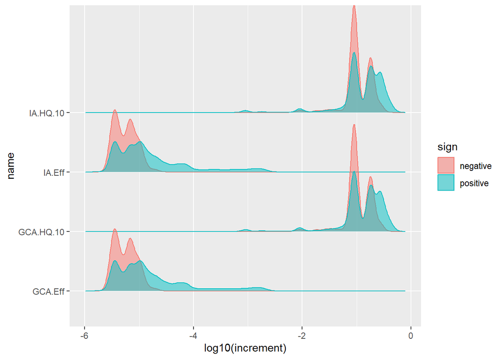

```r
ggplot(td_sensitivity_periodic_signed_pcp, aes(x = log10(increment), y = name, color = sign, fill = sign)) + ggridges::geom_density_ridges(alpha = .5)
```

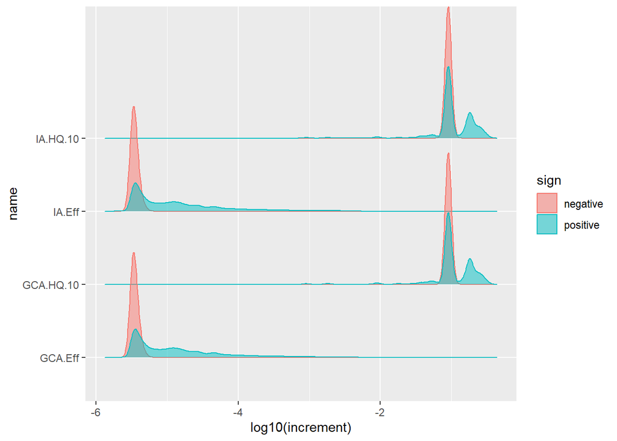

```r
ggplot(td_sensitivity_constant_signed_pcp, aes(x = log10(increment), y = name, color = sign, fill = sign)) + ggridges::geom_density_ridges(alpha = .5)
```

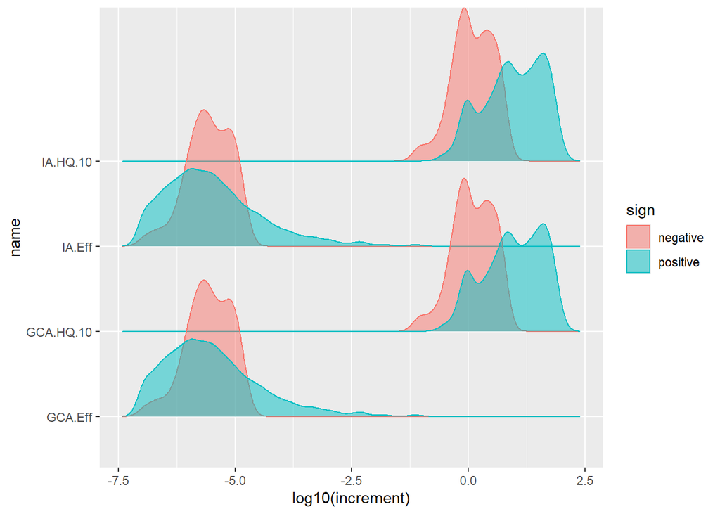

```r
# Plots of signed sensitivity for BPA
ggplot(td_sensitivity_acute_signed_bpa, aes(x = log10(increment), y = name, color = sign, fill = sign)) + ggridges::geom_density_ridges(alpha = .5)
```

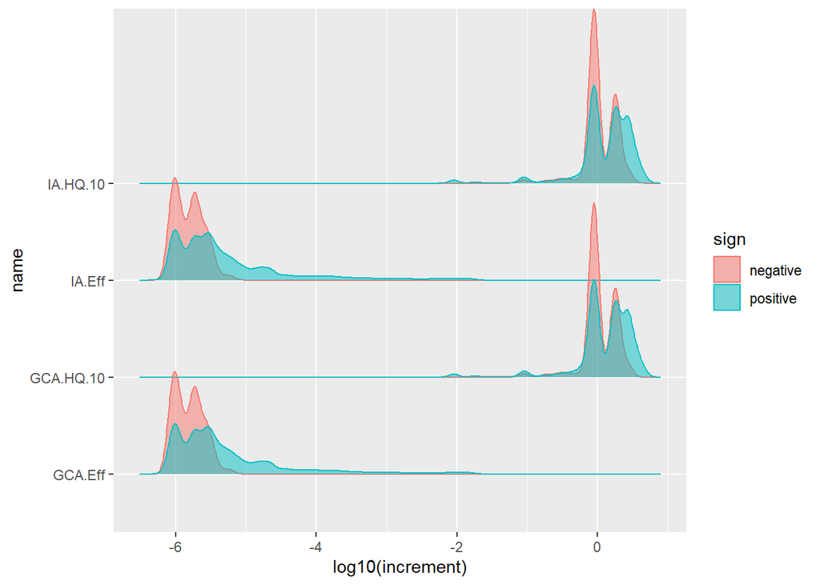

```r
ggplot(td_sensitivity_periodic_signed_bpa, aes(x = log10(increment), y = name, color = sign, fill = sign)) + ggridges::geom_density_ridges(alpha = .5)
```

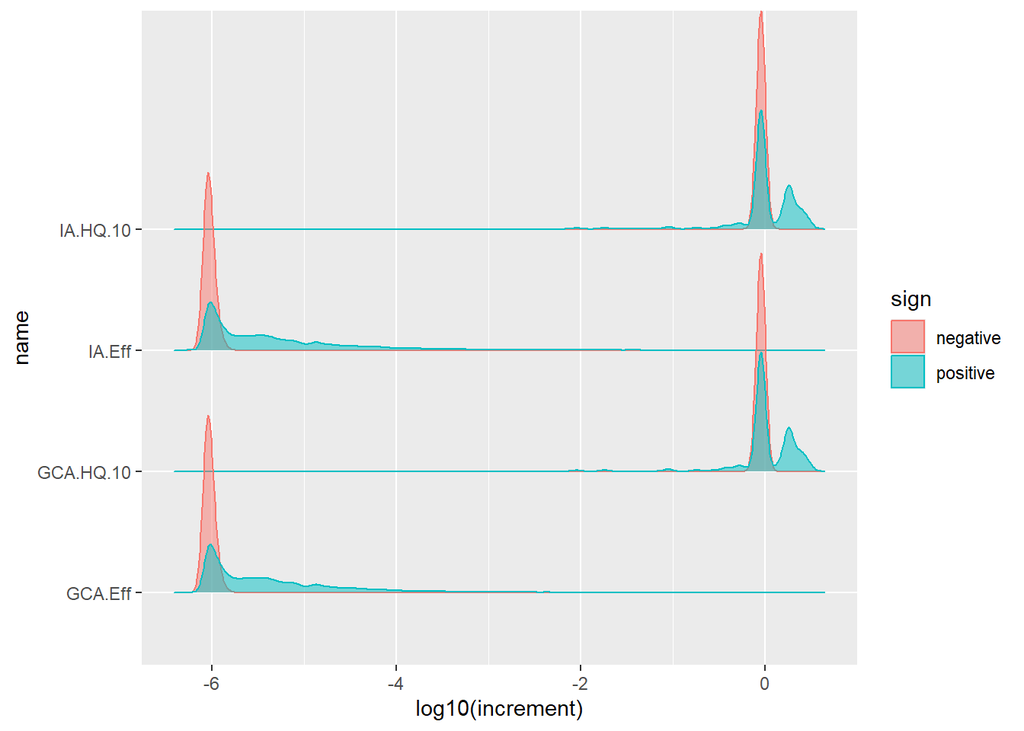

```r
ggplot(td_sensitivity_constant_signed_bpa, aes(x = log10(increment), y = name, color = sign, fill = sign)) + ggridges::geom_density_ridges(alpha = .5)
```

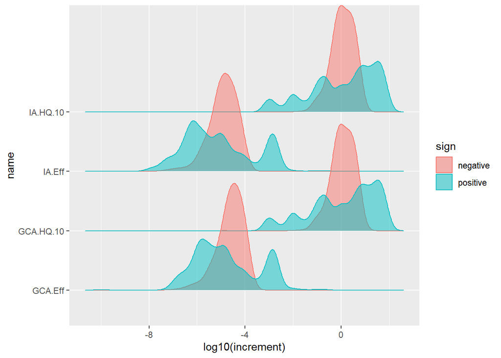

```r
# Plot of signed sensitivity for mixture
ggplot(td_sensitivity_mixture_signed, aes(x = log10(increment), y = name, color = sign, fill = sign)) + ggridges::geom_density_ridges(alpha = .5)
```

We also can examine how sensitive the simulations are to changes in the time resolution. While more frequent readings of ambient air concentrations support more accurate modelling efforts, one may be limited to less frequent readings. How the differences in time resolution impact the blood-plasma concentration and in turn the dose response may in turn inform what time resolution is required for accurate modelling.

We examine the acute, periodic, and constant exposure scenarios under different time resolutions to determine the effects of these resolutions on the plasma concentration values. Note that in each of these scenarios, the time resolution is by the hour, so roughly 0.0416 days. We examine the resolutions of .1, 1, and 2 days.

```r
acute_standard_variability <- time_resolution_variation(chem.cas = '87-86-5', parameters = pbtk_param, plot = TRUE, C_ext = acute_dose_matrix, standardize = TRUE, plot_average = TRUE, resolutions = c(.001, .01, .1, 1, 2), sample = 'left')
```

```
## [1] "time" ""
## [1] "time" "dose"
## [1] "time" "dose"
```

```
## [1] "time" ""
## [1] "time" "dose"
## [1] "time" "dose"
```

```
## [1] "time" ""
## [1] "time" "dose"
## [1] "time" "dose"
```

```r
periodic_standard_variability <- time_resolution_variation(chem.cas = '87-86-5', parameters = pbtk_param, plot = TRUE, C_ext = periodic_dose_matrix, standardize = TRUE, plot_average = TRUE, resolutions = c(.001, .01, .1, 1, 2), sample = 'left')
```

```
## [1] "time" ""
## [1] "time" "dose"
## [1] "time" "dose"
```

```
## [1] "time" ""
## [1] "time" "dose"
## [1] "time" "dose"
```

```
## [1] "time" ""
## [1] "time" "dose"
## [1] "time" "dose"
```

```r
constant_standard_variability <- time_resolution_variation(chem.cas = '87-86-5', parameters = pbtk_param, plot = TRUE, C_ext = constant_dose_matrix, standardize = TRUE, plot_average = TRUE, resolutions = c(.001, .01, .1, 1, 2), sample = 'left')
```

```
## [1] "time" ""
## [1] "time" "dose"
## [1] "time" "dose"
```

```
## [1] "time" ""
## [1] "time" "dose"
## [1] "time" "dose"
```

```
## [1] "time" ""
## [1] "time" "dose"
## [1] "time" "dose"
```

We examine the plots. First the acute exposure scenario.

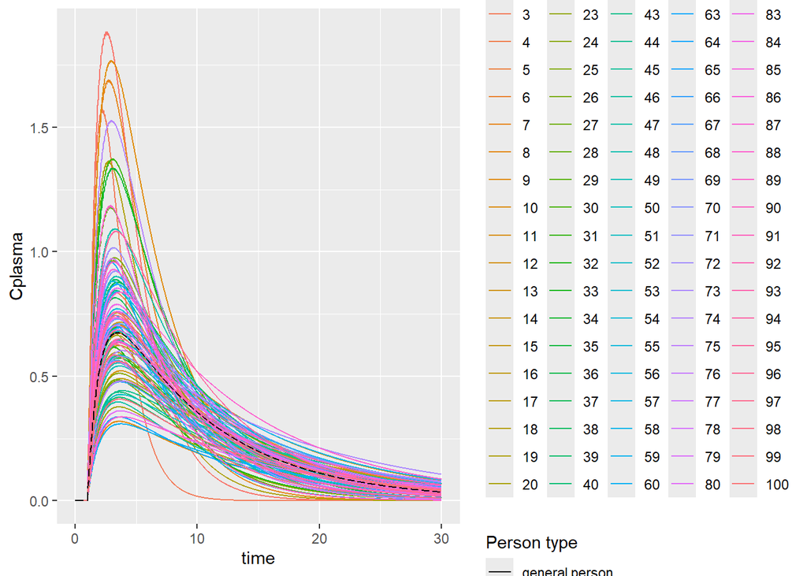

```r
acute_standard_variability$`0.1`$plasma_plot
```

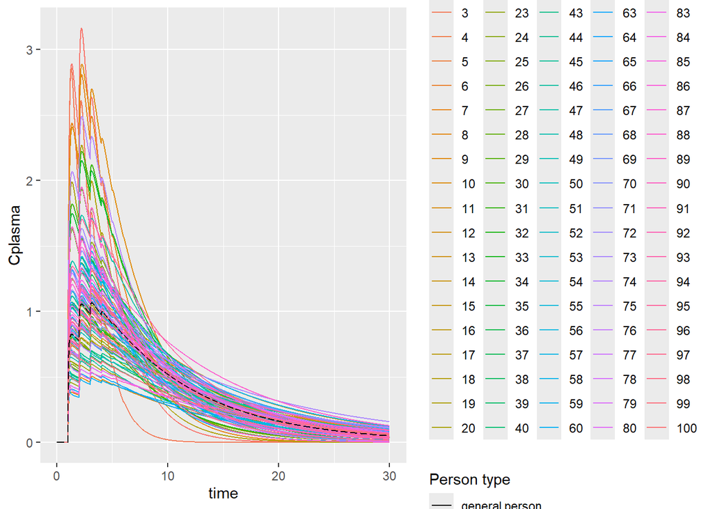

```r
acute_standard_variability$`1`$plasma_plot
```

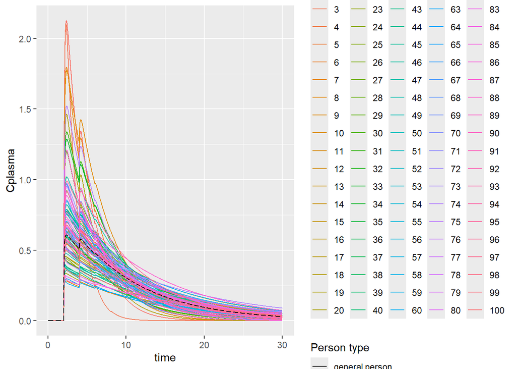

```r
acute_standard_variability$`2`$plasma_plot
```

The periodic scenario.

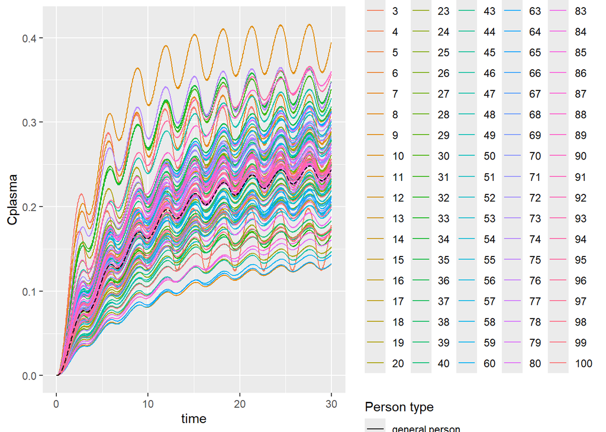

```r
periodic_standard_variability$`0.1`$plasma_plot
```

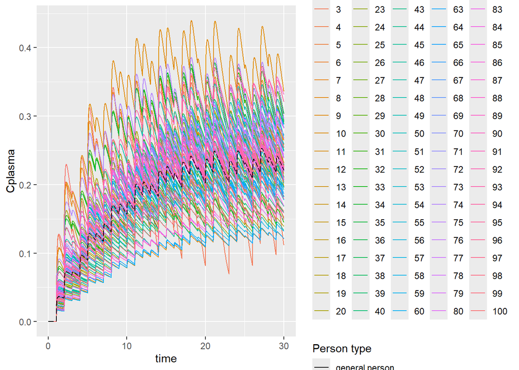

```r
periodic_standard_variability$`1`$plasma_plot
```